# STAT 385 Statistics Programming Methods - Fall 2020

### Other visual considerations

- **alignment**: whether items are straight-edge or not, centered or left/right-justified

**LESS CLUTTER WITH ALIGNMENT**

```r
par(mai=c(0,1,1.5,0))
rb0 <- sort(table(jail$race,jail$weeksbin)[,1])
rbp0 <- barplot( rb0, border=NA ,horiz = TRUE, axes=FALSE,names.arg = "",
                 main="Booking Counts Among Select Races & Ethnicities", col="gray")
rb0
```

```
## Asian/Pacific Islander               Hispanic                  White
##                      0                      4                     14
##                  Black
##                     37
```

```r
rbp0
```

```
##      [,1]
## [1,]  0.7
## [2,]  1.9
## [3,]  3.1
## [4,]  4.3
```

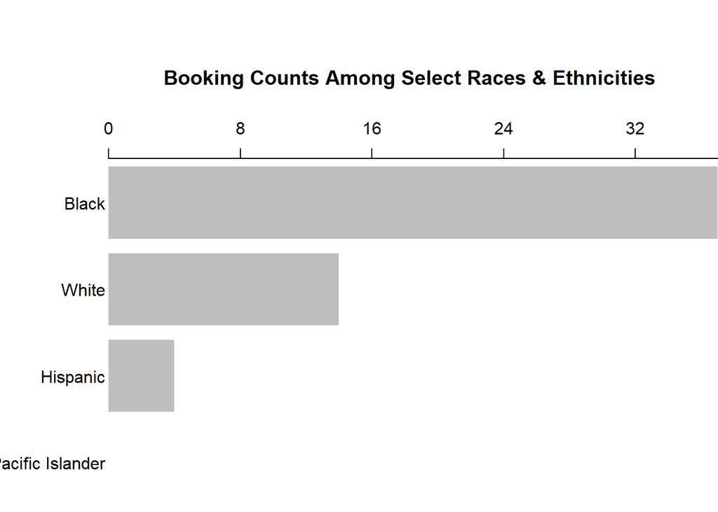

```r
nn <- names(rb0)
nm<-rev(nn)
axis(2, rbp0, las=1, labels=nn, tick=FALSE,mgp=c(3,-0.15,0))
axis(3, at=seq(0, 40, 8), line=-0.25)
```

```r
par(mar=c(5, 4, 4, 2) + 0.1 )
```

- **white space**: white space is powerful and necessary to see variations better

**ORIGINAL**

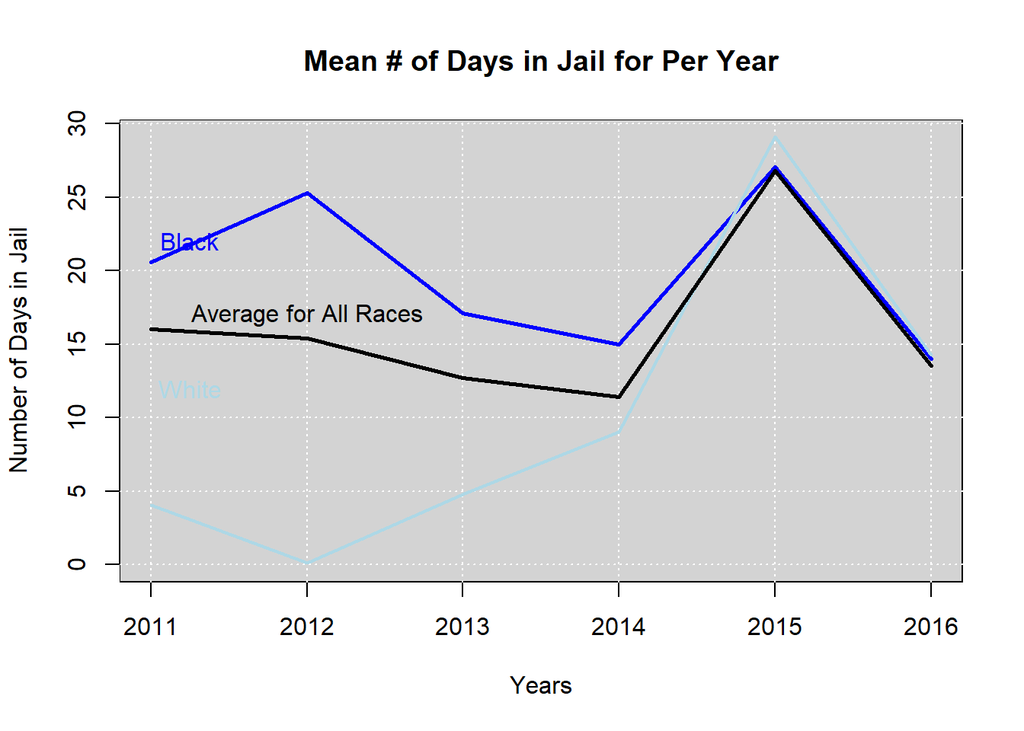

```r
plot(names(daysyrs),daysyrs, type = "n",ylim=c(0,max(daysbla,dayswhi)),xlab="Years",ylab="Number of Days in Jail", main = "Mean # of Days in Jail for Per Year",bty="n")
rect(par("usr")[1],par("usr")[3],par("usr")[2],par("usr")[4],col = "lightgrey")
grid(col="white")
lines(names(daysyrs),daysbla, col="blue",lwd=2.5)
lines(names(daysyrs),dayswhi, col="lightblue", lwd=2)
lines(names(daysyrs),daysyrs, lwd=2.5)
text(2012,17,"Average for All Races")
text(2011.25,22,"Black",col="blue" )
text(2011.25,12,"White",col="lightblue")
```

**LESS CLUTTER WITH WHITE SPACE**

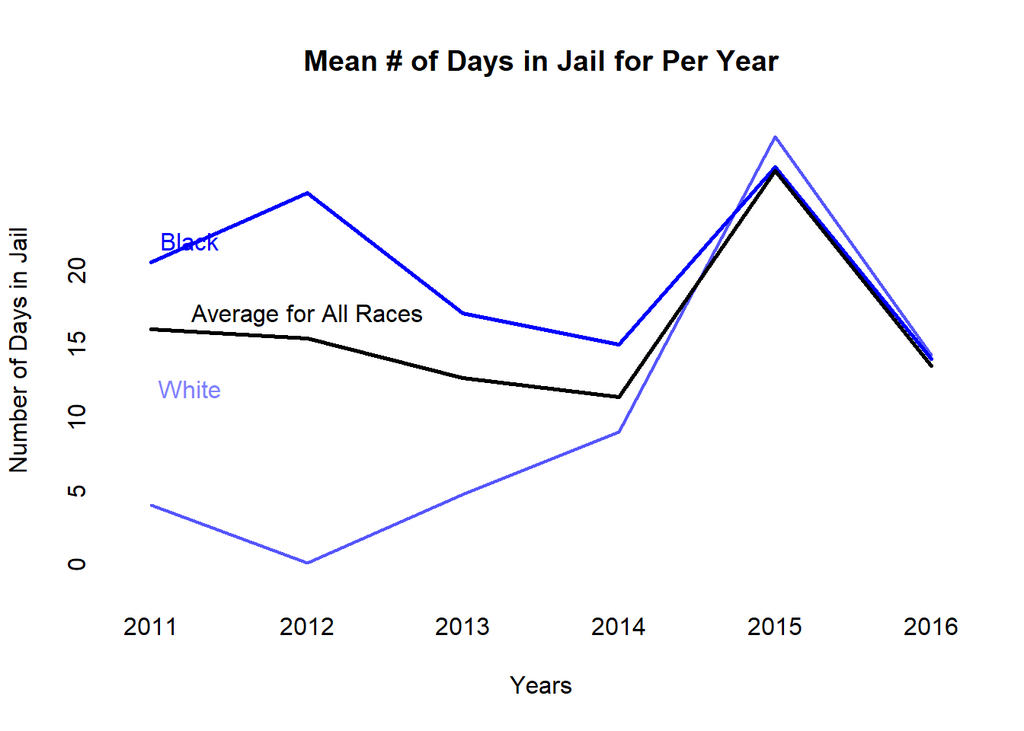

```r
plot(names(daysyrs),daysyrs, type = "n", ylim=c(0,max(daysbla,dayswhi)),xlab="Years",ylab="Number of Days in Jail", main = "Mean # of Days in Jail for Per Year",bty="n", axes =FALSE)
lines(names(daysyrs),daysbla, col="blue",lwd=2.5)
lines(names(daysyrs),dayswhi, col=rgb(0,0,255/255,  alpha=0.667), lwd=2)
lines(names(daysyrs),daysyrs, lwd=2.5)
text(2012,17,"Average for All Races")
text(2011.25,22,"Black",col="blue" )
text(2011.25,12,"White",col=rgb(0,0,255/255,  alpha=0.5))
axis(1, 2011:2016, tick=FALSE)
axis(2, seq(0,20,5), tick=FALSE)
```

- **contrast**: taking advantage of light to show differences

**LESS CLUTTER WITH CONTRAST**

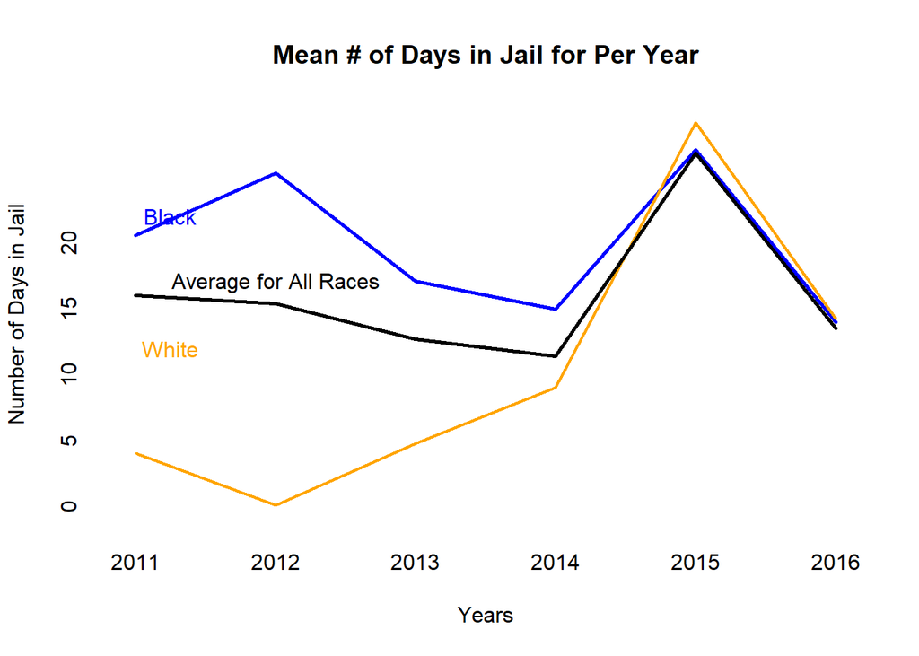

```r
plot(names(daysyrs),daysyrs, type = "n", ylim=c(0,max(daysbla,dayswhi)),xlab="Years",ylab="Number of Days in Jail", main = "Mean # of Days in Jail for Per Year",bty="n", axes =FALSE)
lines(names(daysyrs),daysbla, col="blue",lwd=2.5)
lines(names(daysyrs),dayswhi, col="orange1", lwd=2)
lines(names(daysyrs),daysyrs, lwd=2.5)
text(2012,17,"Average for All Races")
text(2011.25,22,"Black",col="blue" )
text(2011.25,12,"White",col="orange")
axis(1, 2011:2016, tick=FALSE)
axis(2, seq(0,20,5), tick=FALSE)
```

### **Storytelling with Data** *Ch. 4 Focus Your Audience’s Attention*

#### Preattentive attributes

These (size, shape, color, position, etc.) can be used to direct your audience’s attention to where you want and to create a visual hierarchy of elements

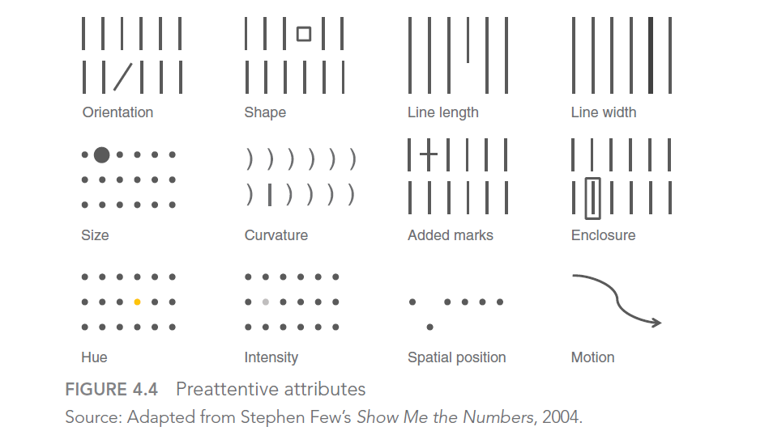

Knaflic’s Storytelling with Data Fig. 4.4

#### Preattentive *text*

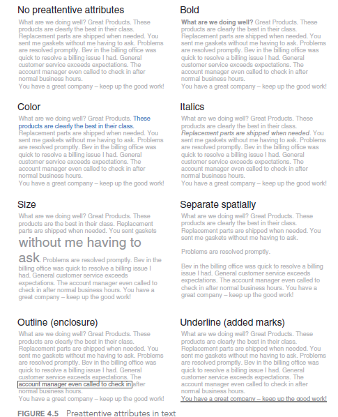

**VISUAL HIERARCHY**

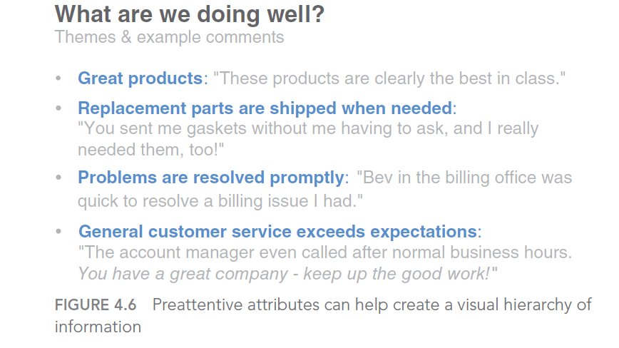

Knaflic’s Storytelling with Data Fig. 4.6

#### Preattentive *plots*

**ORIGINAL**

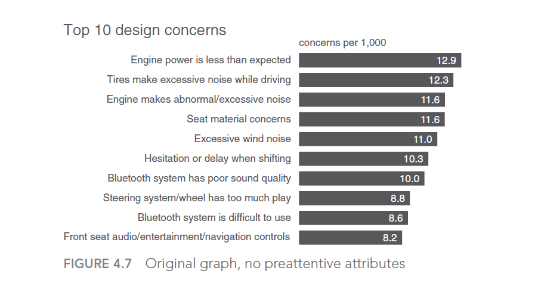

Knaflic’s Storytelling with Data Fig. 4.7

**IMPROVED**

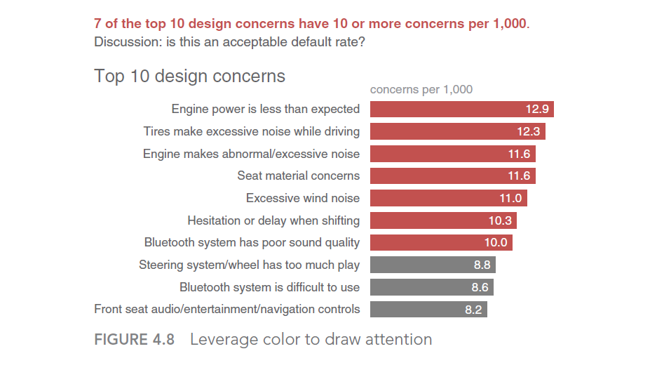

Knaflic’s Storytelling with Data Fig. 4.8

**MORE IMPROVED**

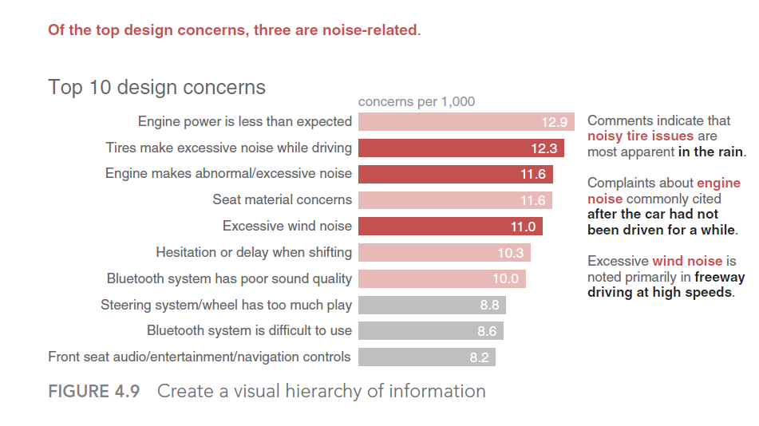

Knaflic’s Storytelling with Data Fig. 4.9

### **Storytelling with Data** *Ch. 5 Think Like a Designer*

As designers e should care about **form** (what we want the audience to do with the data) and **function** (the visualization that allows the function to happen with ease)

#### Affordance

Affordances are aspects that tell the audience how to *use* and *interact* with the data visualizations.

- Use preattentive attributes smartly and sparingly.
- Preattentive attributes can overwhelm and distract if used too often in the same visualization
- Does my visualization need this to make it interpretable?

#### Accessibility

As designers we should be considerate of the audience’s abilities and technical skills, making sure everyone in the room has the chance to interpret our work.

- Remove unnecessary complexity in favor of simplicity.
- Because of colorblindness, consider avoiding red and green in favor of blue and orange.
- Use text smartly.
- If you want the audience to reach a specific conclusion, write it in the visualization.

#### Aesthetics

Pretty and attractive visualizations allows the audience to be patient with us (as presenters) and builds their tolerance of our designs i.e. data visualizations.

- Use color sparingly.
- Organize items on the page to be aligned vertically and horizontally. Using grid lines to guide your eyes as you are making the placement decision.
- Don’t be afraid of white space. Use it often!

#### Acceptance

Good design is only good if the audience accepts the design.

- Using side-by-side visualizations helps to persuade an audience that your visualization is better.
- Show your designs to colleagues and others for feedback before presenting to your audience.